# Alyssa Bockman and Thalia Koutsougeras

CMPS 3160

**Final Project** - Food Access in Louisiana

**Github**: https://github.com/abfender/abfender.github.io

# Project Plan

**Project Description and Goals**: If we use this dataset, we will examine the disparities in food access in Louisiana. We will investigate if any factors play a role in food access, such as access to a vehicle, income level, age, racem and receival of SNAP benefits. We aim to compare these different factors against each other, as well as to compare multiple factors against each other in order to determine correlations.

Data from USDA's Food Access Research Atlas:

https://www.ers.usda.gov/data-products/food-access-research-atlas/download-the-data/

**Collaboration Plan**: Our collaboration plan is to meet at least once a week over zoom on Wednesday nights. We met in person twice to work on Milestone 1. We already have each other’s phone numbers, and we have set up our private Github repository where we uploaded our preliminary notebook files.

# Data Selection and Filtering

```python
# First we mount colab to google drive
from google.colab import drive
drive.mount('/content/drive')
%cd /content/drive/My Drive/cmps3160
%cd dsproj
```

```
/content/drive/My Drive/cmps3160
/content/drive/My Drive/cmps3160/dsproj
```

The data from the original dataset contains 75,000 rows of data, so in order to make the loading process easier, we created another sheet by selecting only the Louisiana rows and exported it as a csv file, which we subsequently read into this notebook.

```python
import pandas as pd
import matplotlib.pyplot as plt

# Reading in the file and storing as a dataframe
df = pd.read_csv("FoodAccessResearchAtlasData2019csv.csv")

# Printing out the first few lines of the dataframe
df.head()
```

|  | CensusTract | State | County | Urban | Pop2010 | OHU2010 | GroupQuartersFlag | NUMGQTRS | PCTGQTRS | LILATracts_1And10 | ... | TractSeniors | TractWhite | TractBlack | TractAsian | TractNHOPI | TractAIAN | TractOMultir | TractHispanic | TractHUNV | TractSNAP |
| --- | --- | --- | --- | --- | --- | --- | --- | --- | --- | --- | --- | --- | --- | --- | --- | --- | --- | --- | --- | --- | --- |
| 0 | 22001960100 | Louisiana | Acadia Parish | 1 | 6213 | 2345 | 0 | 133 | 2.14 | 1 | ... | 871 | 4102 | 1937 | 5 | 1 | 16 | 152 | 118 | 232 | 603 |
| 1 | 22001960200 | Louisiana | Acadia Parish | 0 | 5988 | 2144 | 0 | 0 | 0.00 | 0 | ... | 648 | 5535 | 293 | 14 | 0 | 11 | 135 | 154 | 92 | 182 |
| 2 | 22001960300 | Louisiana | Acadia Parish | 0 | 3582 | 1286 | 0 | 69 | 1.93 | 0 | ... | 421 | 3419 | 75 | 11 | 2 | 16 | 59 | 62 | 114 | 97 |
| 3 | 22001960400 | Louisiana | Acadia Parish | 0 | 6584 | 2362 | 0 | 52 | 0.79 | 0 | ... | 729 | 6253 | 209 | 12 | 0 | 18 | 92 | 75 | 248 | 246 |
| 4 | 22001960500 | Louisiana | Acadia Parish | 0 | 6093 | 2178 | 0 | 43 | 0.71 | 0 | ... | 582 | 5574 | 401 | 8 | 2 | 16 | 92 | 98 | 15 | 330 |

5 rows × 147 columns

```python
# We select the columns that are relevant to our interests because there are 147 columns in the original dataset.
col_list = ["CensusTract", "State", "County", "Urban", "POP2010", "OHU2010", "HUNVFlag", "LowIncomeTracts", "PovertyRate", "MedianFamilyIncome", "TractLOWI", "TractKids", "TractSeniors",
            "TractWhite", "TractBlack", "TractAsian", "TractNHOPI", "TractAIAN", "TractOMultir", "TractHispanic", "TractHUNV", "TractSNAP"]

# We drop all of the columns except for those we are interested in in col_list.
df.drop(columns=df.columns.difference(col_list), inplace=True)
df.head()
```

|  | CensusTract | State | County | Urban | OHU2010 | HUNVFlag | LowIncomeTracts | PovertyRate | MedianFamilyIncome | TractLOWI | ... | TractSeniors | TractWhite | TractBlack | TractAsian | TractNHOPI | TractAIAN | TractOMultir | TractHispanic | TractHUNV | TractSNAP |
| --- | --- | --- | --- | --- | --- | --- | --- | --- | --- | --- | --- | --- | --- | --- | --- | --- | --- | --- | --- | --- | --- |
| 0 | 22001960100 | Louisiana | Acadia Parish | 1 | 2345 | 1 | 1 | 32.0 | 46691.0 | 3105 | ... | 871 | 4102 | 1937 | 5 | 1 | 16 | 152 | 118 | 232 | 603 |
| 1 | 22001960200 | Louisiana | Acadia Parish | 0 | 2144 | 0 | 0 | 6.1 | 83250.0 | 1670 | ... | 648 | 5535 | 293 | 14 | 0 | 11 | 135 | 154 | 92 | 182 |
| 2 | 22001960300 | Louisiana | Acadia Parish | 0 | 1286 | 1 | 1 | 22.1 | 60214.0 | 1286 | ... | 421 | 3419 | 75 | 11 | 2 | 16 | 59 | 62 | 114 | 97 |
| 3 | 22001960400 | Louisiana | Acadia Parish | 0 | 2362 | 1 | 0 | 13.3 | 75458.0 | 2137 | ... | 729 | 6253 | 209 | 12 | 0 | 18 | 92 | 75 | 248 | 246 |
| 4 | 22001960500 | Louisiana | Acadia Parish | 0 | 2178 | 0 | 0 | 14.3 | 76911.0 | 1976 | ... | 582 | 5574 | 401 | 8 | 2 | 16 | 92 | 98 | 15 | 330 |

5 rows × 21 columns

# Preliminary Data Analysis

We choose to analyze some variables using scatterplots.

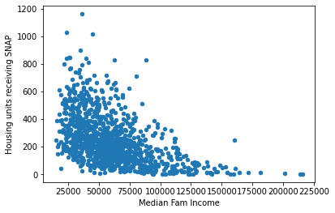

```python
# We compare median family income with TractSNAP.
# This is particularly important to our question because it shows that lower income areas tend to have more SNAP benefits, which is an expected correlation.
df.plot.scatter(x="MedianFamilyIncome", y="TractSNAP", xlabel = "Median Fam Income", ylabel = "Housing units receiving SNAP")
```

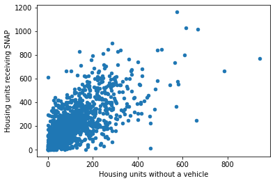

```python
# We compare the number of houses without a vehicle to those who receive SNAP benefits.
df.plot.scatter(x="TractHUNV", y="TractSNAP", xlabel = "Housing units without a vehicle", ylabel = "Housing units receiving SNAP")
```

```python
%%shell

jupyter nbconvert --to html "/content/drive/My Drive/cmps3160/dsproj/Tiral.ipynb"
```

```
[NbConvertApp] Converting notebook /content/drive/My Drive/cmps3160/dsproj/Tiral.ipynb to html
[NbConvertApp] Writing 355079 bytes to /content/drive/My Drive/cmps3160/dsproj/Tiral.html
```